```python
%%shell
jupyter nbconvert --to html /content/Final_Project_Bopst_Wong.ipynb
```

```
[NbConvertApp] Converting notebook /content/Final_Project_Bopst_Wong.ipynb to html
[NbConvertApp] Writing 1556005 bytes to /content/Final_Project_Bopst_Wong.html
```

# An Evaluation of Apartments and Rent

Spring 2024 Data Science Project

Marcus Wong and Connor Bopst

Contribution Checkpoints:

A: Project idea - 5% B: Dataset Curation and Preprocessing - 10% C: Data Exploration and Summary Statistics - 10% D: ML Algorithm Design/Development - 25% E: ML Algorithm Training and Test Data Analysis - 20% F: Visualization, Result Analysis, Conclusion - 15% G: Final Tutorial Report Creation - 10% H: Additional (not listed above, if any) - 5%

Member 1: Marcus Wong, Contribution: 100%.

Member 2: Connor Bopst, Contribution: 100%.

"We, all team members, agree together that the above information is true, and we are confident about our contributions to this submitted project/final tutorial."

Marcus Wong 5/7/2024

Connor Bopst 5/7/2024

Connor Bopst - Proposed the idea of using the apartments dataset as well as cleaned up the data and make the plots with the maps. Also did the heat map. Did the neural network model

Marcus Wong - Wrote the introduction, conclusion, pushed the web page to the git repository. Did the scatter plots as well as the linear regression model. Did the analysis for linear regression model.

Introduction: In the United States, few economic factors are as ubiquitous to everyone as the cost of rent. It's a metric that not only reflects economic vitality but also holds important implications for individuals and families across the nation.

In this evaluation, we look to see what factors have an affect on rent prices and look at especially at how location affects the price of rent. It is important that we look at what affects rent because rent affordability directly impacts individuals and families, influencing their quality of life, financial stability, and even economic mobility.

```python
import pandas as pd
import numpy as np
import seaborn as sns
import matplotlib.pyplot as plt
from scipy import stats
import geopandas as gpd
import pandas as pd
from shapely.geometry import Point
import sklearn as sk
import keras
import tensorflow
from tensorflow.keras.models import Sequential
from tensorflow.keras.layers import Dense
from tensorflow.keras.layers import Dropout
#from scikeras.wrappers import KerasRegressor
from sklearn.model_selection import cross_val_score
from sklearn.model_selection import KFold
from sklearn.preprocessing import StandardScaler
from sklearn.pipeline import Pipeline
from sklearn.model_selection import train_test_split
from sklearn.linear_model import LinearRegression
from sklearn.metrics import mean_absolute_error, mean_squared_error, r2_score
```

Dataset Source: https://www.kaggle.com/datasets/adithyaawati/apartments-for-rent-classified

Data Curation: This is a dataset of classified for apartments for rent in USA from various rental listing agency platforms. The dataset contains both 100,000 rental entries and 22 columns.

```python
df = pd.read_table("apartments_for_rent_classified_100K.csv", delimiter = ';', encoding= 'ISO-8859-1', low_memory=False)
```

```python
df.head()
```

|  | id | category | title | body | amenities | bathrooms | bedrooms | currency | fee | has_photo | ... | price_display | price_type | square_feet | address | cityname | state | latitude | longitude | source | time |
| --- | --- | --- | --- | --- | --- | --- | --- | --- | --- | --- | --- | --- | --- | --- | --- | --- | --- | --- | --- | --- | --- |
| 0 | 5668640009 | housing/rent/apartment | One BR 507 & 509 Esplanade | This unit is located at 507 & 509 Esplanade, R... | NaN | 1.0 | 1.0 | USD | No | Thumbnail | ... | $2,195 | Monthly | 542 | 507 509 Esplanade | Redondo Beach | CA | 33.8520 | -118.3759 | RentLingo | 1577360355 |
| 1 | 5668639818 | housing/rent/apartment | Three BR 146 Lochview Drive | This unit is located at 146 Lochview Drive, Ne... | NaN | 1.5 | 3.0 | USD | No | Thumbnail | ... | $1,250 | Monthly | 1500 | 146 Lochview Dr | Newport News | VA | 37.0867 | -76.4941 | RentLingo | 1577360340 |
| 2 | 5668639686 | housing/rent/apartment | Three BR 3101 Morningside Drive | This unit is located at 3101 Morningside Drive... | NaN | 2.0 | 3.0 | USD | No | Thumbnail | ... | $1,395 | Monthly | 1650 | 3101 Morningside Dr | Raleigh | NC | 35.8230 | -78.6438 | RentLingo | 1577360332 |
| 3 | 5668639659 | housing/rent/apartment | Two BR 209 Aegean Way | This unit is located at 209 Aegean Way, Vacavi... | NaN | 1.0 | 2.0 | USD | No | Thumbnail | ... | $1,600 | Monthly | 820 | 209 Aegean Way | Vacaville | CA | 38.3622 | -121.9712 | RentLingo | 1577360330 |
| 4 | 5668639374 | housing/rent/apartment | One BR 4805 Marquette NE | This unit is located at 4805 Marquette NE, Alb... | NaN | 1.0 | 1.0 | USD | No | Thumbnail | ... | $975 | Monthly | 624 | 4805 Marquette NE | Albuquerque | NM | 35.1038 | -106.6110 | RentLingo | 1577360308 |

5 rows × 22 columns

```python
df.dtypes
```

[output not shown]

One thing we will look into is the time dimension to the data. It is stored as an integer currently. However, we will disregard it for now and treat our data as a cross-section. We will explore adding time back later.

```python
# Here we check for any missing values
def missval(s):
  num = df[s].isnull().sum()
  print('there are ' + str(num) + ' missing values in ' + str(s))

for i in df.columns:
  missval(i)
```

```
there are 0 missing values in id
there are 0 missing values in category
there are 0 missing values in title
there are 0 missing values in body
there are 16044 missing values in amenities
there are 63 missing values in bathrooms
there are 124 missing values in bedrooms
there are 0 missing values in currency
there are 0 missing values in fee
there are 0 missing values in has_photo
there are 60424 missing values in pets_allowed
there are 1 missing values in price
there are 1 missing values in price_display
there are 0 missing values in price_type
there are 0 missing values in square_feet
there are 91549 missing values in address
there are 302 missing values in cityname
there are 302 missing values in state
there are 25 missing values in latitude
there are 25 missing values in longitude
there are 0 missing values in source
there are 0 missing values in time
```

```python
df = df.drop(columns= ['address', 'pets_allowed', 'amenities'])
df = df.dropna()
for i in df.columns:
  missval(i)
```

```
there are 0 missing values in id
there are 0 missing values in category
there are 0 missing values in title
there are 0 missing values in body
there are 0 missing values in bathrooms
there are 0 missing values in bedrooms
there are 0 missing values in currency
there are 0 missing values in fee
there are 0 missing values in has_photo
there are 0 missing values in price
there are 0 missing values in price_display
there are 0 missing values in price_type
there are 0 missing values in square_feet
there are 0 missing values in cityname
there are 0 missing values in state
there are 0 missing values in latitude
there are 0 missing values in longitude
there are 0 missing values in source
there are 0 missing values in time
```

We see now that we have no missing values.

the most important features in our dataset are bedrooms, bathrooms, square_feet, cityname, and state. These are the most important features for predicting rental cost.

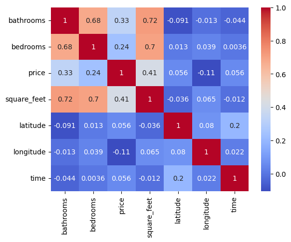

```python
# Here we do some EDA with the corrplot to look for initial correlations
corr = df[df.columns[~df.columns.isin(['id'])]].select_dtypes(include=['float64', 'int64']).corr()

# Generate a heatmap
sns.heatmap(corr, annot=True, cmap='coolwarm')
```

This correlation plot shows correlations between our numeric features. We see the most interesting results in the middle of the plot. Square feet and bedrooms have a correlation coefficient of 0.7, meaning they are positively correlated. The features most strongly correlated with price (the best predictors) are square feet, bathrooms, and bedrooms, in that order. We will be sure to include these in our model.

```python
#we add a variable to create a city and state geographic variable called city_state
df['city_state'] = df['cityname'] + ', ' + df['state']
```

```python
len(df['city_state'].unique())
```

```
3550
```

We added a categorical variable called city_state to see the city-state pairs that our data are in. This also differentiates between cities that have the same name but are in different states. This will give us more insight into where the data are from and will be useful in our model. We see that there are 3,550 unique city-state pairs in our dataset.

Where are our data located? We want to show a distribution of our data across the US so we will use geopandas along with our latitude and longitude data.

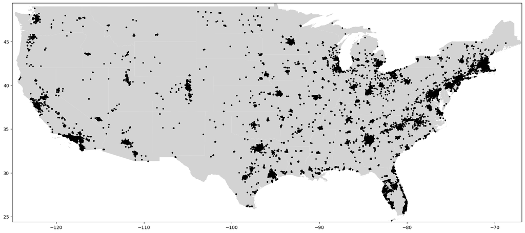

```python
df['geometry'] = [Point(xy) for xy in zip(df['longitude'], df['latitude'])]
gdf = gpd.GeoDataFrame(df, geometry='geometry')

# Here we read in the necessary shape file
shape = gpd.read_file('cb_2018_us_state_500k.shp')

# now we make our plot
fig, ax = plt.subplots(figsize = (20,20))
shape.plot(ax=ax, color='lightgray')
gdf.plot(ax=ax, marker='o', color='black', markersize=5)
ax.set_xlim([-125.0, -66.93457]) # these limits are the latitude and longitude limits of the continental US
ax.set_ylim([24.396308, 49.384358])
plt.show()
```

We see that our data density is pretty concentrated along the coasts, and especially the northeast. Note that Alaska and Hawaii are omitted from our analysis here. Our observations are also clustered in urban population centers (cities). In the midwest especially, we see clusters of high density and then less dense observations around them. This makes sense since most renters live in cities. This distribution makes us think we may want to focus our model on one region where we have high data density rather than trying to create a model for the whole united states.

Below we focus on the DMW, which is where we will explore various models to gain insight and predict rent prices.

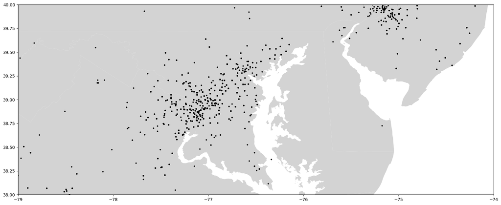

```python
fig, ax = plt.subplots(figsize = (20,20))
shape.plot(ax=ax, color='lightgray')
gdf.plot(ax=ax, marker='o', color='black', markersize=5)
ax.set_xlim([-79.0, -74]) # these limits are the latitude and longitude limits of the continental US
ax.set_ylim([38, 40])
plt.show()
```

```python
df.describe()
```

|  | id | bathrooms | bedrooms | price | square_feet | latitude | longitude | time |
| --- | --- | --- | --- | --- | --- | --- | --- | --- |
| count | 9.900700e+04 | 99007.000000 | 99007.000000 | 99007.000000 | 99007.000000 | 99007.000000 | 99007.000000 | 9.900700e+04 |
| mean | 5.357986e+09 | 1.445893 | 1.728696 | 1525.646197 | 956.072651 | 36.941613 | -91.544174 | 1.559645e+09 |
| std | 1.846415e+08 | 0.547158 | 0.748697 | 898.955283 | 365.387944 | 4.603572 | 15.825494 | 1.104721e+07 |
| min | 5.121046e+09 | 1.000000 | 0.000000 | 100.000000 | 107.000000 | 19.573800 | -159.369800 | 1.544174e+09 |
| 25% | 5.197947e+09 | 1.000000 | 1.000000 | 1013.500000 | 730.000000 | 33.743500 | -104.817100 | 1.550832e+09 |
| 50% | 5.508672e+09 | 1.000000 | 2.000000 | 1350.000000 | 900.000000 | 37.213900 | -84.546500 | 1.568745e+09 |
| 75% | 5.509006e+09 | 2.000000 | 2.000000 | 1795.000000 | 1115.000000 | 39.955900 | -77.576700 | 1.568767e+09 |
| max | 5.669439e+09 | 9.000000 | 9.000000 | 52500.000000 | 12000.000000 | 64.833200 | -68.778800 | 1.577391e+09 |

Above we see summary statistics for our numeric fields in our data. Notice the large outlier in price - $52,500.

Now we want to try to figure out the distribution of our data. The easiest thing to do is just to plot the frequency distribution of prices!

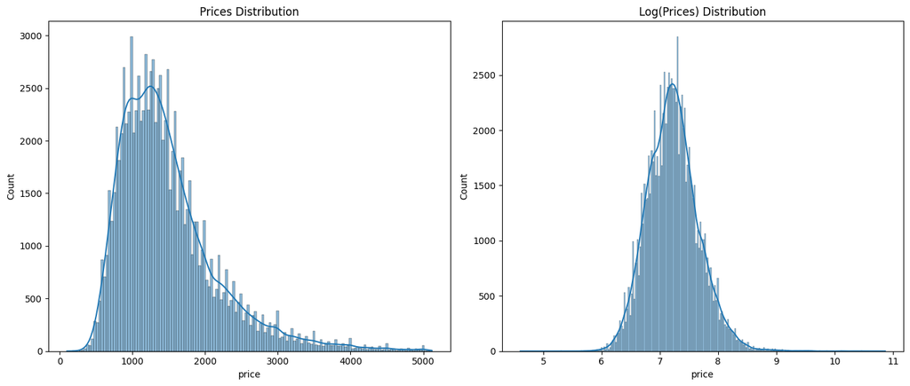

```python
prices = df['price']
log_prices = np.log(df['price'])
# Here we filter out extreme outliers (price z-score > 4) and render a density plot of the prices in our dataset.
prices_no_outliers = prices.where((np.abs(stats.zscore(prices)) < 4)).dropna()


fig, axes = plt.subplots(1, 2, figsize=(14, 6))
sns.histplot(prices_no_outliers, ax=axes[0], kde=True)
axes[0].set_title('Prices Distribution')

sns.histplot(log_prices, ax=axes[1], kde=True)
axes[1].set_title('Log(Prices) Distribution')

plt.tight_layout()
plt.show()
```

This frequency plot of prices on the left shows us that the distribution of rents is centered around ~$1300 but it has a very long tail. This leads us to believe it may be log-normally distributed. Upon taking the log of the prices and doing a frequency plot, we see that it does indeed look normally distributed, providing evidence that our data may be log-normally distribtued.

Now we look for summary statistics by state:

```python
summary_table = df.groupby('state').agg(
    observations=('id', 'count'),
    average_price=('price', 'mean'),
    average_bathrooms=('bathrooms', 'mean'),
    average_bedrooms=('bedrooms', 'mean'),
    avg_sqft=('square_feet', 'mean')
).reset_index()

summary_table.sort_values('average_price', ascending = False)
```

|  | state | observations | average_price | average_bathrooms | average_bedrooms | avg_sqft |
| --- | --- | --- | --- | --- | --- | --- |
| 11 | HI | 31 | 2729.193548 | 1.806452 | 2.322581 | 1067.677419 |
| 34 | NY | 653 | 2541.229709 | 1.287136 | 1.655436 | 950.266462 |
| 4 | CA | 10254 | 2465.646187 | 1.456651 | 1.663741 | 926.831090 |
| 7 | DC | 83 | 2226.795181 | 1.216867 | 1.313253 | 709.506024 |
| 19 | MA | 5026 | 2192.835058 | 1.354457 | 1.848587 | 1011.097493 |
| 31 | NJ | 4442 | 2038.311571 | 1.368415 | 1.585997 | 941.348267 |
| 39 | RI | 119 | 2034.731092 | 1.352941 | 1.823529 | 902.386555 |
| 47 | WA | 2593 | 1826.514848 | 1.457000 | 1.798303 | 918.309294 |
| 20 | MD | 5276 | 1645.684420 | 1.389973 | 1.714936 | 954.396513 |
| 9 | FL | 5768 | 1574.700763 | 1.590499 | 1.832178 | 1043.886442 |
| 5 | CO | 6280 | 1555.071019 | 1.396099 | 1.612898 | 894.315764 |
| 45 | VA | 8281 | 1485.975003 | 1.465282 | 1.744838 | 945.110011 |
| 14 | IL | 1032 | 1485.228682 | 1.244186 | 1.790698 | 901.274225 |
| 37 | OR | 277 | 1475.357401 | 1.326715 | 1.675090 | 924.274368 |
| 30 | NH | 733 | 1454.069577 | 1.251705 | 1.821282 | 910.758527 |
| 46 | VT | 125 | 1415.080000 | 1.132000 | 1.720000 | 978.816000 |
| 23 | MN | 579 | 1389.326425 | 1.284974 | 1.637306 | 883.773748 |
| 10 | GA | 4752 | 1351.296086 | 1.558291 | 1.816919 | 1076.425295 |
| 38 | PA | 1117 | 1300.931961 | 1.305730 | 1.670546 | 913.598030 |
| 44 | UT | 809 | 1300.651422 | 1.461063 | 1.893696 | 986.440049 |
| 6 | CT | 507 | 1267.216963 | 1.212032 | 1.729783 | 908.240631 |
| 21 | ME | 30 | 1250.833333 | 1.050000 | 1.533333 | 736.100000 |
| 48 | WI | 428 | 1231.532710 | 1.239486 | 1.862150 | 933.988318 |
| 43 | TX | 11236 | 1218.115967 | 1.406328 | 1.588644 | 903.924795 |
| 22 | MI | 709 | 1198.060649 | 1.342736 | 1.889986 | 962.655853 |
| 42 | TN | 1114 | 1176.795332 | 1.512567 | 1.772890 | 1016.864452 |
| 33 | NV | 2812 | 1173.551920 | 1.542852 | 1.745377 | 951.700213 |
| 8 | DE | 7 | 1154.857143 | 1.428571 | 1.857143 | 1035.714286 |
| 27 | NC | 6299 | 1153.068582 | 1.566836 | 1.813462 | 1008.387839 |
| 40 | SC | 908 | 1143.715859 | 1.608480 | 1.862335 | 1032.669604 |
| 13 | ID | 96 | 1122.322917 | 1.598958 | 2.000000 | 1010.833333 |
| 3 | AZ | 2375 | 1120.110737 | 1.488421 | 1.738947 | 913.647158 |
| 26 | MT | 87 | 1118.344828 | 1.356322 | 2.011494 | 1000.425287 |
| 35 | OH | 4902 | 1110.922481 | 1.438698 | 1.774990 | 969.710322 |
| 0 | AK | 57 | 1054.280702 | 1.236842 | 1.701754 | 798.175439 |
| 24 | MO | 1202 | 1048.308652 | 1.334859 | 1.705491 | 919.806156 |
| 18 | LA | 1344 | 1026.380952 | 1.463914 | 1.744048 | 966.372024 |
| 15 | IN | 503 | 1017.178926 | 1.390656 | 1.874751 | 948.681909 |
| 36 | OK | 932 | 1016.113734 | 1.575644 | 1.803648 | 973.568670 |
| 17 | KY | 992 | 990.305433 | 1.454637 | 1.740927 | 948.871976 |
| 1 | AL | 352 | 962.176136 | 1.549716 | 1.917614 | 1039.599432 |
| 12 | IA | 371 | 950.212938 | 1.330189 | 1.849057 | 908.916442 |
| 28 | ND | 740 | 946.277027 | 1.489865 | 2.006757 | 1011.570270 |
| 29 | NE | 1019 | 933.348381 | 1.348381 | 1.601570 | 909.544652 |
| 16 | KS | 911 | 918.930845 | 1.406696 | 1.751921 | 941.621295 |
| 41 | SD | 86 | 887.651163 | 1.290698 | 1.709302 | 955.093023 |
| 2 | AR | 598 | 874.367893 | 1.556856 | 1.819398 | 971.740803 |
| 25 | MS | 107 | 874.158879 | 1.584112 | 2.000000 | 1034.439252 |
| 49 | WV | 13 | 871.769231 | 1.538462 | 2.230769 | 1238.307692 |
| 32 | NM | 24 | 844.041667 | 1.083333 | 1.458333 | 706.833333 |
| 50 | WY | 16 | 791.750000 | 1.562500 | 2.000000 | 965.125000 |

Hypothesis Test 1:

Rent for a one-bedroom, one-bathroom apartment is the same price per square foot in Boston as it is in DC.

H_0: The location of Boston vs. DC has no significant effect on the price per square foot of a one bedroom, one bathroom apartment.

H_A: The location of Boston vs. DC has a significant effect on the price per square foot of a one bedroom, one bathroom apartment.

```python
BO_DC = df[df['city_state'].isin(['Boston, MA', 'Washington, DC']) & (df['bedrooms'] == 1.0) & (df['bathrooms'] == 1.0)]
BO_DC.head()

BO_DC['PPSFT'] = BO_DC['price'] / BO_DC['square_feet']
# Separate PPSFT values into arrays for each city.
boston_ppsft = BO_DC.loc[BO_DC['city_state'] == 'Boston, MA', ['PPSFT']]
washington_ppsft = BO_DC.loc[BO_DC['city_state'] == 'Washington, DC', ['PPSFT']]

t_test_result = stats.ttest_ind(boston_ppsft, washington_ppsft, equal_var=True)

# Print the t-test result (t-statistic and p-value)
print(f't-statistic: {t_test_result.statistic}, p-value: {t_test_result.pvalue}')
```

```
t-statistic: [4.34413119], p-value: [2.04604125e-05]
```

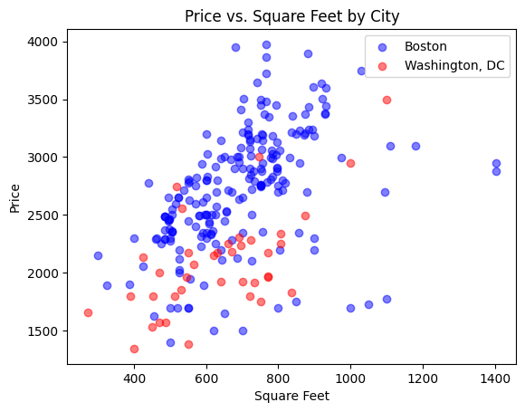

```python
boston_data = BO_DC.loc[BO_DC['city_state'] == 'Boston, MA', ['price', 'square_feet']]
washington_data = BO_DC.loc[BO_DC['city_state'] == 'Washington, DC', ['price', 'square_feet']]

plt.scatter(boston_data['square_feet'], boston_data['price'], color='blue', alpha=0.5, label='Boston')
plt.scatter(washington_data['square_feet'], washington_data['price'], color='red', alpha=0.5, label='Washington, DC')

plt.title('Price vs. Square Feet by City')
plt.xlabel('Square Feet')
plt.ylabel('Price')
plt.legend()
plt.show()
```

Hypothesis test 2:

Studio apartments in Washington, DC are more expensive than one-bedroom apartments in Baltimore City.

H_0: the mean rent of a Studio in Washington, DC is the same as or less than a one-bedroom apartment in Baltimore city

H_1: the mean rent of a studio in Washington, DC is higher than that of a one-bedroom apartment in Baltimore city

```python
BA_DC = df[df['city_state'].isin(['Baltimore, MD', 'Washington, DC'])]

baltimore_price = BA_DC.loc[(BA_DC['city_state'] == 'Baltimore, MD') & (BA_DC['bedrooms'] == 1) , ['price']]
washington_price = BA_DC.loc[(BA_DC['city_state'] == 'Washington, DC') & (BA_DC['bedrooms'] == 0), ['price']]

t_test_result = stats.ttest_ind(washington_price, baltimore_price,  equal_var=False)

print(f't-statistic: {t_test_result.statistic}, p-value: {t_test_result.pvalue}')
```

```
t-statistic: [3.91777674], p-value: [0.00031138]
```

We see that the p-value of 0.0003 < 0.025, which is half of our total threshold 0.05, since we are doing a one-tailed test. Since our t-statistic is positive, that means that a one-bedroom apartment in baltimore is cheaper than a studio apartment in Washington, DC on average.

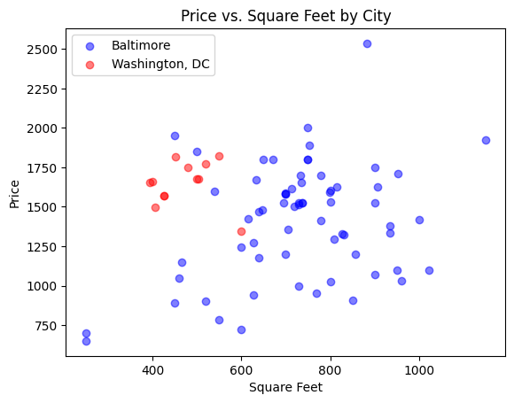

```python
# Plot Baltimore data
baltimore_data = BA_DC.loc[(BA_DC['city_state'] == 'Baltimore, MD') & (BA_DC['bedrooms'] == 1),['square_feet', 'price']]
washington_data = BA_DC.loc[(BA_DC['city_state'] == 'Washington, DC') & (BA_DC['bedrooms'] == 0),['square_feet', 'price']]

plt.scatter(baltimore_data['square_feet'], baltimore_data['price'], color='blue', alpha=0.5, label='Baltimore')
plt.scatter(washington_data['square_feet'], washington_data['price'], color='red', alpha=0.5, label='Washington, DC')

plt.title('Price vs. Square Feet by City')
plt.xlabel('Square Feet')
plt.ylabel('Price')
plt.legend()

# Show plot
plt.show()
```

H_0: There is no significant difference in the average rental prices of apartments based on the number of bedrooms.

H_A: There is a significant difference in the average rental prices of apartments based on the number of bedrooms.

Test Method: One-way Analysis of Variance (ANOVA)

α = 0.05

```python
from scipy.stats import f_oneway
grouped_data = df.groupby('bedrooms')
groups = [group[1]['price'] for group in grouped_data]
f_statistic, p_value = f_oneway(*groups)
print("ANOVA p-value:", p_value)
```

```
ANOVA p-value: 0.0
```

Our P-value is lower than the significance level of 0.05 so we reject the null hypothesis

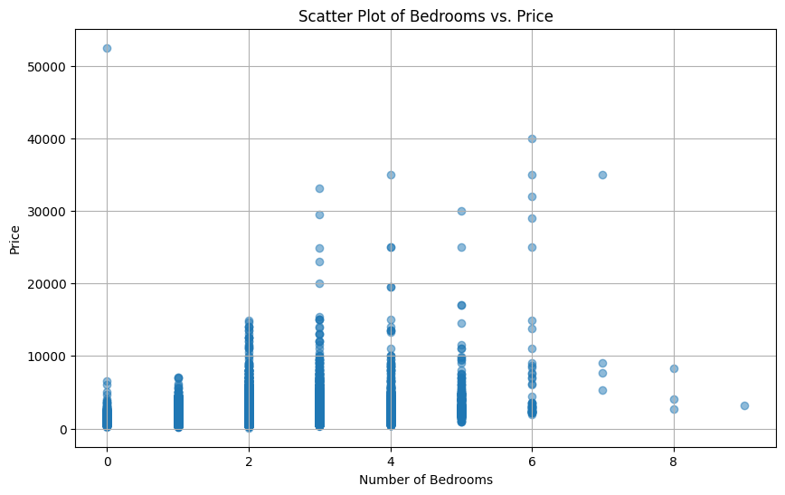

```python
plt.figure(figsize=(10, 6))
plt.scatter(df['bedrooms'], df['price'], alpha=0.5)
plt.title('Scatter Plot of Bedrooms vs. Price')
plt.xlabel('Number of Bedrooms')
plt.ylabel('Price')
plt.grid(True)
plt.show()
```

Primary Analysis: Linear Regression By training a linear regression model with the square footage as the input feature and the rental price as the target variable, the model learns the relationship between the size of the apartment and its corresponding rental price. Once trained, we can see the relationship between the two variables and also predict the rental price based off of the square footage.

```python
from sklearn.linear_model import Ridge
from sklearn.preprocessing import PolynomialFeatures, StandardScaler
from sklearn.pipeline import make_pipeline

# Load the dataset
# Drop rows with missing values in 'square_feet' and 'price' columns
df = df.dropna(subset=['square_feet'])

X = df[['square_feet']]
y = df['price']

# Split the data into training and testing sets
X_train, X_test, y_train, y_test = train_test_split(X, y, test_size=0.2, random_state=42)

model = LinearRegression()
model.fit(X_train, y_train)

# Predict on the testing data
y_pred = model.predict(X_test)

mse = mean_squared_error(y_test, y_pred)
print("Mean Squared Error:", mse)
```

```
Mean Squared Error: 626269.268629577
```

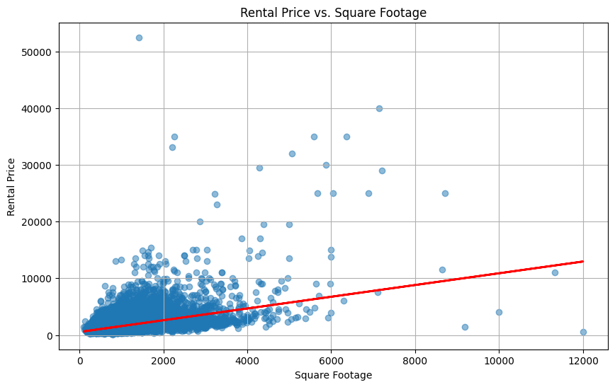

```python
plt.figure(figsize=(10, 6))
plt.scatter(df['square_feet'], df['price'], alpha=0.5)
plt.title('Rental Price vs. Square Footage')
plt.xlabel('Square Footage')
plt.ylabel('Rental Price')
plt.grid(True)
plt.plot(X, model.predict(X), color='red', linewidth=2)
plt.show()
```

Here we can see that the two are positively correlated meaning that as the square footage of an apartment goes up, the rent does too. This all makes sense since landlords will often charge higher rents for larger apartments due to the increased living space and amenities they offer. This aligns with the basic economic principle of supply and demand, where larger apartments may be in higher demand, allowing landlords to command higher prices.

Building on our regression model where we regress rent price on square footage, we now put together a fixed-effect regression model that attempts to explain rent prices in the DC-MD-VA area using all of our available features.

```python
import statsmodels.api as sm
import statsmodels.formula.api as smf

df1 = df[['price','bathrooms', 'bedrooms', 'square_feet','latitude','longitude','state', 'city_state']].dropna()
df1 = df1[df1['state'].isin(['MD', 'VA', 'DC'])]
df1['state'] = df1['state'].astype('category')
df1['city_state'] = df1['city_state'].astype('category')

df1['price'] = np.log(df1['price'])

# Define the regression formula
formula = 'price ~ latitude + longitude + C(city_state) + C(state) + C(city_state)*latitude + C(city_state)*longitude + bathrooms + bedrooms + square_feet'
model = smf.ols(formula=formula, data=df1).fit()

results_summary = model.summary()
results_as_html = results_summary.tables[1].as_html()
summary_df = pd.read_html(results_as_html, header=0, index_col=0)[0]

print(results_summary)
```

```
                            OLS Regression Results
==============================================================================
Dep. Variable:                  price   R-squared:                       0.761
Model:                            OLS   Adj. R-squared:                  0.754
Method:                 Least Squares   F-statistic:                     116.8
Date:                Wed, 08 May 2024   Prob (F-statistic):               0.00
Time:                        03:19:47   Log-Likelihood:                 5662.0
No. Observations:               13640   AIC:                        -1.060e+04
Df Residuals:                   13277   BIC:                            -7868.
Df Model:                         362
Covariance Type:            nonrobust
=======================================================================================================================
                                                          coef    std err          t      P>|t|      [0.025      0.975]
-----------------------------------------------------------------------------------------------------------------------
Intercept                                            6760.2246   5528.746      1.223      0.221   -4076.905    1.76e+04
C(city_state)[T.Abingdon, MD]                           0.0228      0.017      1.336      0.182      -0.011       0.056
C(city_state)[T.Abingdon, VA]                          -0.3083      5.558     -0.055      0.956     -11.202      10.586
C(city_state)[T.Adelphi, MD]                            0.0152      0.010      1.465      0.143      -0.005       0.036
C(city_state)[T.Alexandria, VA]                     -3099.1839      2e+04     -0.155      0.877   -4.24e+04    3.62e+04
C(city_state)[T.Altavista, VA]                          2.7460      2.806      0.978      0.328      -2.755       8.247
C(city_state)[T.Annandale, VA]                          2.7859      2.884      0.966      0.334      -2.868       8.440
C(city_state)[T.Annapolis Junction, MD]                 0.0118      0.008      1.457      0.145      -0.004       0.028
C(city_state)[T.Annapolis, MD]                      -2.244e+04   1.06e+04     -2.125      0.034   -4.31e+04   -1738.772
C(city_state)[T.Arlington, VA]                      -3202.7809      2e+04     -0.160      0.873   -4.25e+04    3.61e+04
C(city_state)[T.Arnold, MD]                             0.0007      0.007      0.104      0.917      -0.012       0.014
C(city_state)[T.Ashburn, VA]                        -3160.1662      2e+04     -0.158      0.875   -4.24e+04    3.61e+04
C(city_state)[T.Ashland, VA]                            2.7886      2.896      0.963      0.336      -2.887       8.465
C(city_state)[T.Baltimore, MD]                      -2.372e+04   8715.141     -2.722      0.007   -4.08e+04   -6636.229
C(city_state)[T.Baskerville, VA]                        2.7754      2.873      0.966      0.334      -2.857       8.407
C(city_state)[T.Bealeton, VA]                           2.7735      2.858      0.971      0.332      -2.828       8.375
C(city_state)[T.Bedford, VA]                            2.7379      2.790      0.981      0.326      -2.730       8.206
C(city_state)[T.Bel Air, MD]                          -12.6012      4.871     -2.587      0.010     -22.149      -3.053
C(city_state)[T.Belcamp, MD]                            0.0005      0.001      0.585      0.559      -0.001       0.002
C(city_state)[T.Beltsville, MD]                         0.0138      0.010      1.438      0.151      -0.005       0.033
C(city_state)[T.Bethesda, MD]                       -2.373e+04   8715.194     -2.723      0.006   -4.08e+04   -6646.081
C(city_state)[T.Big Stone Gap, VA]                      2.6589      2.628      1.012      0.312      -2.493       7.811
C(city_state)[T.Blacksburg, VA]                         2.7654      2.772      0.998      0.318      -2.667       8.198
C(city_state)[T.Bladensburg, MD]                        0.0122      0.010      1.167      0.243      -0.008       0.033
C(city_state)[T.Bowie, MD]                           -2.38e+04   8717.313     -2.730      0.006   -4.09e+04   -6715.299
C(city_state)[T.Bowling Green, VA]                      2.7894      2.896      0.963      0.335      -2.887       8.466
```

[output cut: 680 more lines]

```
C(city_state)[T.Yorktown, VA]:longitude              -240.3399     91.732     -2.620      0.009    -420.148     -60.532
bathrooms                                               0.1472      0.004     34.108      0.000       0.139       0.156
bedrooms                                               -0.0166      0.003     -5.519      0.000      -0.023      -0.011
square_feet                                             0.0003   7.31e-06     40.549      0.000       0.000       0.000
==============================================================================
Omnibus:                     1275.824   Durbin-Watson:                   1.820
Prob(Omnibus):                  0.000   Jarque-Bera (JB):             8444.582
Skew:                          -0.173   Prob(JB):                         0.00
Kurtosis:                       6.839   Cond. No.                     1.05e+16
==============================================================================

Notes:
[1] Standard Errors assume that the covariance matrix of the errors is correctly specified.
[2] The smallest eigenvalue is 1.23e-22. This might indicate that there are
strong multicollinearity problems or that the design matrix is singular.
```

```python
import tensorflow as tf
from tensorflow.keras import layers, models
from sklearn.preprocessing import StandardScaler, OneHotEncoder
import numpy as np
from tensorflow.keras import backend as K

df1 = df[['price','bathrooms', 'bedrooms', 'square_feet','latitude','longitude','cityname', 'state']].dropna()
df1 = df1[df1['state'].isin(['MD', 'VA', 'DC'])]
df1 = df1.drop_duplicates()
df1 = df1.dropna()

target = df1['price']
features = df1.drop(columns='price')

scaler = StandardScaler()
features[['square_feet', 'bedrooms', 'bathrooms']] = scaler.fit_transform(features[['square_feet', 'bedrooms', 'bathrooms']])

statedummies = pd.get_dummies(features['state']).reset_index(drop = True)
citydummies = pd.get_dummies(features['cityname']).reset_index(drop = True)

features = features.drop(columns=['state', 'cityname'])
fulldummies = pd.concat([statedummies, citydummies], axis = 1)
features = features.reset_index(drop = True)

# Concatenate all
features = pd.concat([features.reset_index(drop = True), fulldummies], axis=1)
features = features.astype('float32')
```

```python
X_train, X_test, Y_train, Y_test = train_test_split(features, target, test_size=0.2, random_state=42)

# define the model
model = Sequential([
    Dense(241, input_dim=241, activation='relu'),
    Dense(128, activation='relu'),
    Dropout(0.1),
    Dense(128, activation = 'relu'),
    Dropout(0.1),
    Dense(64, activation = 'relu'),
    Dense(1, activation='linear')  # For regression, the output layer has 1 neuron and linear activation since this is a regression problem
])

# Here I define the R^2 function so we can compare the two models
def r_squared(y_true, y_pred):
    SS_res =  K.sum(K.square(y_true - y_pred))
    SS_tot = K.sum(K.square(y_true - K.mean(y_true)))
    return (1 - SS_res/(SS_tot + K.epsilon()))

model.compile(optimizer='adam', loss='mean_squared_error', metrics = r_squared)

# Summary of the model
model.summary()
history = model.fit(X_train, Y_train, epochs=50, batch_size=32, validation_split=0.2, verbose=1)
```

```
Model: "sequential_12"
_________________________________________________________________
 Layer (type)                Output Shape              Param #
=================================================================
 dense_52 (Dense)            (None, 241)               58322

 dense_53 (Dense)            (None, 128)               30976

 dropout_8 (Dropout)         (None, 128)               0

 dense_54 (Dense)            (None, 128)               16512

 dropout_9 (Dropout)         (None, 128)               0

 dense_55 (Dense)            (None, 64)                8256

 dense_56 (Dense)            (None, 1)                 65

=================================================================
Total params: 114131 (445.82 KB)
Trainable params: 114131 (445.82 KB)
Non-trainable params: 0 (0.00 Byte)
_________________________________________________________________
```

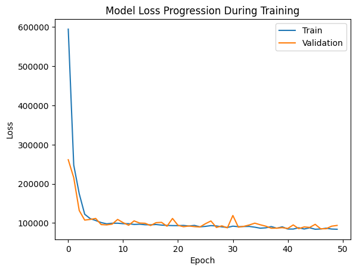

```python
plt.plot(history.history['loss'], label='Train Loss')
plt.plot(history.history['val_loss'], label='Validation Loss')
plt.title('Model Loss Progression During Training')
plt.ylabel('Loss')
plt.xlabel('Epoch')
plt.legend(['Train', 'Validation'], loc='upper right')
plt.show()
```

```python
results = model.evaluate(X_test, Y_test, verbose=1)
print("Test MSE, Test R-Squared:", results)
```

```
Test MSE, Test R-Squared: [86934.0078125, 0.684881865978241]
```

Conclusions: We test two different model specifications:

1. A Fixed-effects regression model with state-level and city-state pair level fixed effeects

Our regression equation is as follows: $price = \beta_1latitude + \beta_2longitude + \beta_3bathrooms + \beta_4bedrooms + \beta_5square\_feet + \beta_6C(city\_state) + \beta_7C(state) + \beta_8C(city\_state)*latitude + \beta_9C(city\_state)*longitude$  
Notice that we include interctions between the city_state dummies and latitude and longitude to capture nonlinearity in the relationships.

We evaluated the models based on their $R^2$ score. We defined the $R^2$ manually for the neural network since TensorFlow does not include it as a base option.

The Regression model had an adjusted-$R^2$ value of 0.754 The Neural Network model had a test $R^2$ value of 0.684

By this metric, the Regression model outperformed the neural network. A further benefit of the regression model is that it is far more interpretable than the neural network. the regression coefficients in the model give us the effects of a one-unit change in each variable on the price of a house.

One of the main challenges we have with this problem is that the only locational features we have are latitude and longitude. The effects of latitude and longitude on price are very localized and nonlinear as individual neighborhoods. We tried to address this by including interaction terms between our city dummies and latitude and longitude. This helped a bit but did not fully alleviate the problem. In the network, we were unable to include these nonlinearities so that may be one reason the model did not perform as well.